# Patch Notes: Diving Deeper Into Steam’s Recommendations

## Plotting and Scheming

I started the data exploration phase of this project by grabbing the nearest thing I could write on and jotting down whatever came to mind in terms of interesting data visualisations using my data. (This ended up being a poor unsuspecting receipt)

Looking back, It seems that I managed to (sort of) stick to my initial plan, although the order of the plots was altered. For plot three, I originally intended to only compare the frequency of indie games between the first and second batches of data, because I noticed the genre was very prevalent in my data set. In the end, I decided to plot the change in frequency of all genres across batches.

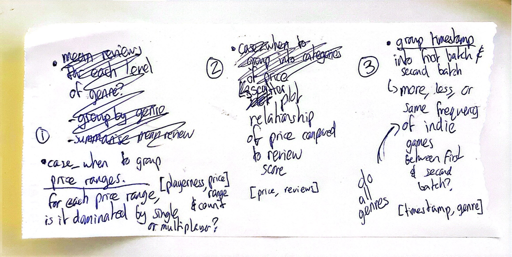

*For reference: Steam’s “Recommended Based On The Games You Play” tab*

[figure not shown]

Screenshot of Steam’s “Recommended Based On The Games You Play” tab

## Price vs. Praise

In my personal experience, I’ve always been quicker to judge/evaluate expensive things than I have been for cheap or free things. However, if I’ve already bought something expensive, I’m probably much more likely to defend that decision by looking for its qualities rather than its imperfections… right?

Steam only allows users to submit reviews if they own the video game that they’re reviewing, which gives us the perfect opportunity to determine just how true this is for Steam’s customers. I started by gathering all the price points in my data set and grouping them up into distinct “price ranges”.

- Low = $0 - $9
- Budget = $10 - $29
- Standard = $30 - $59
- Premium = $60+

Using these new price ranges and the data gathered on each game’s overall review score in a box and whisker plot, I produced the following visualisation:

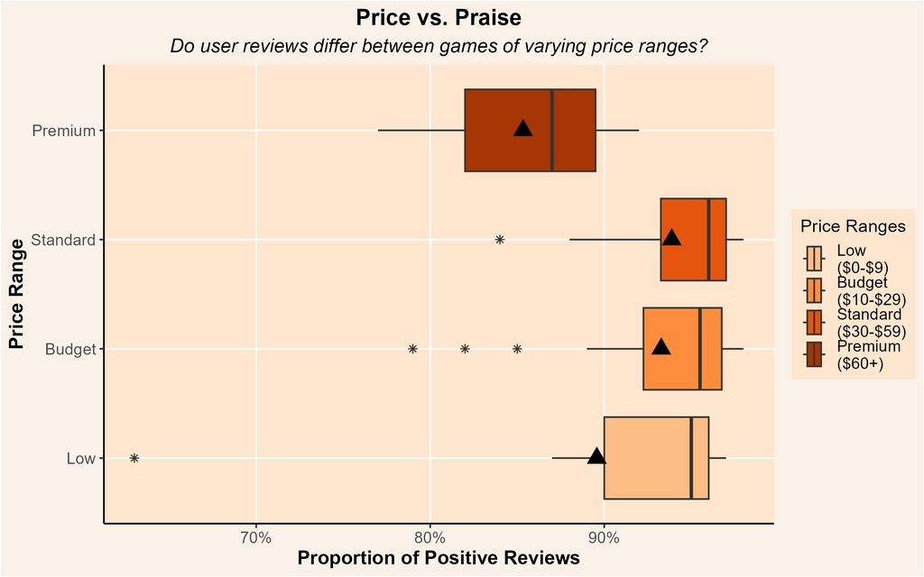

*(Ranges sorted from most to least expensive)*

*(Means denoted by black triangles, outliers denoted by asterisks)*

After an analysis of this visualisation, I made the following observations:

- Games in the “Premium” price range ($60+) tended to have lower proportions of positive reviews than games in all other price ranges.
- Games in the “Budget” price range were most susceptible to outliers.
- The game with the lowest review score was in the “Low” price range, although it was an extreme outlier. (Upon further investigation, this game was one of the two free games in my data set).
- Games in the “Standard” price range were most likely to have a higher proportion of positive reviews.

## The More, The… Spendier?

My understanding of monetisation in gaming is that the most lucrative games tend to be entirely free-to-play. The word *“play”*, however, is doing a lot of heavy lifting in that description. A lot of games, most typically online multiplayer games, will be completely free to install and play–these games instead opt to make their money through cosmetics, in-app purchases, and subscriptions.

Given that understanding, I expected Multiplayer games to dominate the “Low” price range and expected Singleplayer games to thrive in the higher price ranges. After analysing my visualisation, however…

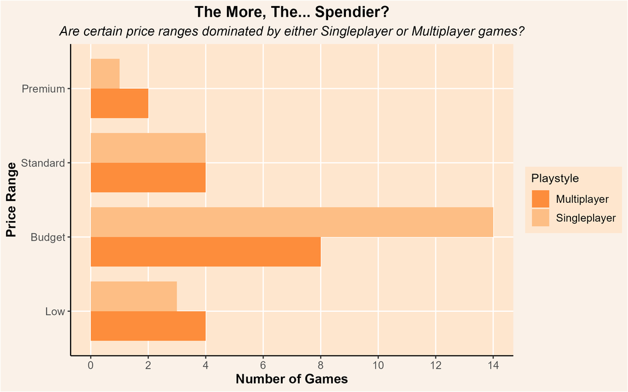

*(Ranges sorted from most to least expensive)*

I found that Singleplayer games were extremely predominant in the “Budget” price range, and while Multiplayer games were slightly more present than Singleplayer games in the “Low” price range, it wasn’t by very much at all. Interestingly, the counts of each playstyle were tied in the “Standard” price range.

While not much can be said for the “Premium”, “Standard”, and “Low” price ranges (the differences between the counts of Multiplayer and Singleplayer games could very easily be due to random chance), it’s clear that, for the games that Steam has recommended to me, games in the “Budget” price range are dominated by Singleplayer games.

## Round 2!

While the relationships I had been exploring did pique my interest, I wanted to get a more personalised understanding of the data I had been gathering. It’s been just over a month since I last collected data for my Google Sheet, so it’s entirely possible that Steam’s idea of my “perfect game” has adapted since then. To investigate this possibility, I grouped up my entries by their timestamps to determine whether the entry was gathered for the first batch (Project 2) or the second batch (Project 4).

I wanted to create a unique visualisation for my third and final plot, so I created my own take on a “lollipop chart” which compares the occurrences of each genre between each batch. Equivalent values across both batches are joined together, and greater values reach past lesser values to express the difference between the two.

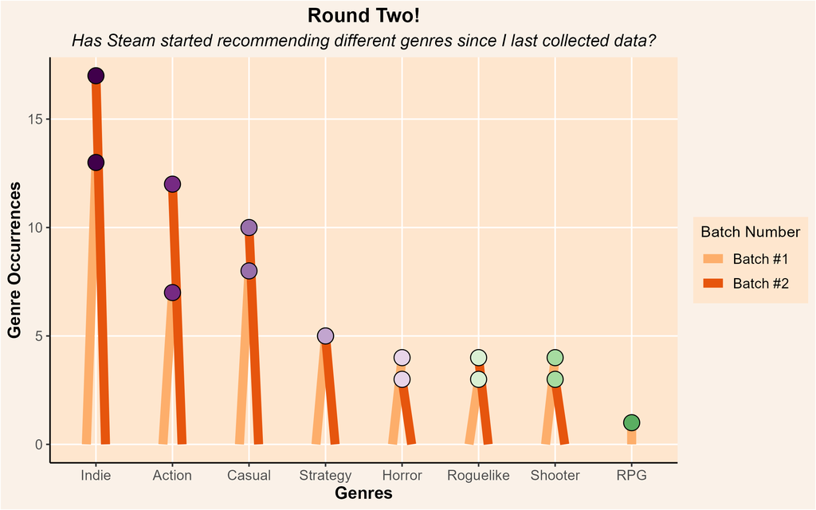

I noticed the following details after an analysis of my plot:

- Indie and Action games were much more prevalent in my second batch of data.
- There were zero RPG games in my second batch of data.
- Most other genres tended to maintain a similar number of occurrences throughout both batches of data
- The average game in my second batch of data tended to fall under more genres at once than the average game in my first batch, meaning occurrence counts were slightly higher overall for games in the second batch.